# STAT 240 Discussion 8

## Questions

### 1

1. A fair coin is tossed repeatedly until the tenth head is tossed. $X_1$ is the number of tails tossed prior to the tenth head.

2. Four buckets each contain a total of five tokens each, some red and some blue. The number of red tokens in the buckets are 1, 2, 3, and 4 with blue tokens making up the remainder. One token is drawn at random from each bucket. $X_2$ is the total number of red tokens drawn.

3. A random sample of students in a fitness study. $X_3$ is the mean systolic blood pressure of the sample.

### 2

Let $X \sim \text{Binomial}(25, 0.4)$.

#### A

Calculate and report the mean $\mu = \mathsf{E}(X)$ and the standard deviation $\sigma = \sqrt{\mathsf{Var}(X)}$.

#### B

Calculate $\mathsf{P}(X \ge 14)$.

### C

Create a graph of the $\text{Binomial}(25, 0.4)$ distribution. Color the segments for $x = 14, 15, \ldots, 25$ red and use gray for the rest. Plot using `theme_minimal()`.

You may edit the code in this block which does something similar for a different problem. Note the use of `geom_binom_density()` with different values of `a` and `b`.

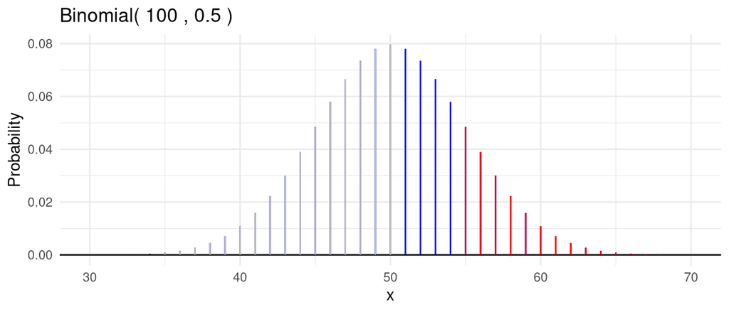

```r
gbinom(100, 0.5, a = 30, b = 70) +
  geom_binom_density(100, 0.5, a = 35, b = 50, color = "gray") +
  geom_binom_density(100, 0.5, a = 55, b = 70, color = "red") +
  theme_minimal()
```

### 3

Create a data frame with columns `n`, `p`, `x`, `mu`, and `prob` where:

- `n` varies from 2 to 100 by twos (so each `n` value is even: 2, 4, 6, 8, …, 100);
- `p` equals 0.5;
- `x` is `n*p`;
- `mu` is the mean of the Binomial distribution with parameters `n` and `p`;
- `prob` is $\mathsf{P}(X = x)$, where $X \sim ~ \text{Binomial}(n, p)$

Show the first few rows using `head()`, then respond to the question below.

What is the relationship between `x` and `mu`?

### 4

The central limit theorem implies that the binomial distribution converges to a normal distribution as $n$ increases. This problem will examine one aspect of the convergence, namely the right tail probability of being more than two standard deviations above the mean, $\mathsf{P}(X > \mu + 2\sigma)$.

**(a)** What is the probability that a normal random variable with mean $\mu$ and standard deviation $\sigma$ exceeds $\mu + 2 \sigma$? Display answer rounded to four decimal places.

**(b)**

Create a data frame with columns `n`, `p`, `mu`, `sigma`, `x`, and `prob` where:

- `n` varies from 1 to 1000 by ones (1, 2, 3, …, 1000);
- `p` equals 0.5;
- `mu` is the mean of the Binomial distribution with parameters `n` and `p`
- `sigma` is the standard deviation of the Binomial distribution with parameters `n` and `p`;
- `x = mu` + 2*sigma`;
- `prob` is $\mathsf{P}(X > x)$, where $X \sim \text{Binomial}(n, p)$

Display the first few rows of the data frame with `head()`.

**(c)** Plot the right tail probabilities versus $n$, and carryout the following modifications:

- Add a red, dashed, horizontal line at the value you found in part **(a)**.
- Add a smooth curve which lessens the visual impact of the oscillations due to the discreteness of the binomial distribution.

### 5

Repeat problems **4B** and **4C** if $p = 0.005$.

### 5D

Ignoring the oscillations, how do the patterns of the two smooth curves in the graphs differ from one another, especially when $n$ is large?

### 6

Draw a graph of the binomial distribution with $(n=500, p = 0.5)$ and a graph for the binomial distribution with $(n=500, p = 0.005)$; you may use the `gbinom()` function in the *ggprob.R* script. Scale these graphics so that the x axis is restricted to where the probabilities are relatively large; set `scale=TRUE` in the `gbinom()` function to accomplish this.

Overlay each plot with a red normal density with a mean and standard deviation that matches the mean and standard deviation of the corresponding binomial distribution. Consider the `geom_norm_density()` function in the *ggprob.R* script.

### 7

If $X \sim \text{N}(20, 3)$, what is $\mathsf{P}(15 < X < 27)$?

### 8

Draw a graph of a normal distribution with mean 20 and standard deviation 3 with the area between 15 and 27 shaded. How does this area correspond to the previous calculated probability?

### 9

Define $z_1 = (15 - 20)/3$ and $z_2 = (27 - 20)/3$. If $Z \sim \text{N}(0,1)$, what is $\mathsf{P}(z_1 < Z < z_2)$?

### 10

Draw a graph of a standard normal distribution and shade the area under the curve between $z_1$ and $z_2$ from the previous problem. How does this plotted graph compare to the graph made in question 8?